# Risk Factor Analysis

## Outcome Variable

**Outcome Variable:** ever_swasted

## Predictor Variables

**Intervention Variable:** parity

**Adjustment Set:**

- arm
- W_mage
- meducyrs
- feducyrs
- hhwealth_quart
- W_mhtcm
- W_mwtkg
- W_mbmi
- vagbrth
- W_nrooms
- impsan
- delta_W_mage
- delta_meducyrs
- delta_feducyrs
- delta_hhwealth_quart
- delta_W_mhtcm
- delta_W_mwtkg
- delta_W_mbmi
- delta_vagbrth
- delta_W_nrooms
- delta_impsan

## Stratifying Variables

The analysis was stratified on these variable(s):

- agecat
- studyid
- country

## Data Summary

| agecat | studyid | country | parity | ever_swasted | n_cell | n |
| --- | --- | --- | --- | --- | --- | --- |
| 0-24 months | COHORTS | GUATEMALA | 1 | 0 | 191 | 1341 |
| 0-24 months | COHORTS | GUATEMALA | 1 | 1 | 17 | 1341 |
| 0-24 months | COHORTS | GUATEMALA | 2 | 0 | 172 | 1341 |
| 0-24 months | COHORTS | GUATEMALA | 2 | 1 | 15 | 1341 |
| 0-24 months | COHORTS | GUATEMALA | 3+ | 0 | 881 | 1341 |
| 0-24 months | COHORTS | GUATEMALA | 3+ | 1 | 65 | 1341 |
| 0-24 months | COHORTS | INDIA | 1 | 0 | 737 | 4624 |
| 0-24 months | COHORTS | INDIA | 1 | 1 | 73 | 4624 |
| 0-24 months | COHORTS | INDIA | 2 | 0 | 1082 | 4624 |
| 0-24 months | COHORTS | INDIA | 2 | 1 | 102 | 4624 |
| 0-24 months | COHORTS | INDIA | 3+ | 0 | 2336 | 4624 |
| 0-24 months | COHORTS | INDIA | 3+ | 1 | 294 | 4624 |
| 0-24 months | COHORTS | PHILIPPINES | 1 | 0 | 584 | 3045 |
| 0-24 months | COHORTS | PHILIPPINES | 1 | 1 | 93 | 3045 |
| 0-24 months | COHORTS | PHILIPPINES | 2 | 0 | 609 | 3045 |
| 0-24 months | COHORTS | PHILIPPINES | 2 | 1 | 73 | 3045 |
| 0-24 months | COHORTS | PHILIPPINES | 3+ | 0 | 1470 | 3045 |
| 0-24 months | COHORTS | PHILIPPINES | 3+ | 1 | 216 | 3045 |
| 0-24 months | GMS-Nepal | NEPAL | 1 | 0 | 158 | 686 |
| 0-24 months | GMS-Nepal | NEPAL | 1 | 1 | 45 | 686 |
| 0-24 months | GMS-Nepal | NEPAL | 2 | 0 | 127 | 686 |
| 0-24 months | GMS-Nepal | NEPAL | 2 | 1 | 53 | 686 |
| 0-24 months | GMS-Nepal | NEPAL | 3+ | 0 | 224 | 686 |
| 0-24 months | GMS-Nepal | NEPAL | 3+ | 1 | 79 | 686 |
| 0-24 months | JiVitA-3 | BANGLADESH | 1 | 0 | 9487 | 26956 |
| 0-24 months | JiVitA-3 | BANGLADESH | 1 | 1 | 639 | 26956 |
| 0-24 months | JiVitA-3 | BANGLADESH | 2 | 0 | 8441 | 26956 |
| 0-24 months | JiVitA-3 | BANGLADESH | 2 | 1 | 493 | 26956 |
| 0-24 months | JiVitA-3 | BANGLADESH | 3+ | 0 | 7383 | 26956 |
| 0-24 months | JiVitA-3 | BANGLADESH | 3+ | 1 | 513 | 26956 |

[output cut: 168 more lines]

The following strata were considered:

- agecat: 0-24 months, studyid: COHORTS, country: GUATEMALA
- agecat: 0-24 months, studyid: COHORTS, country: INDIA
- agecat: 0-24 months, studyid: COHORTS, country: PHILIPPINES
- agecat: 0-24 months, studyid: GMS-Nepal, country: NEPAL
- agecat: 0-24 months, studyid: JiVitA-3, country: BANGLADESH
- agecat: 0-24 months, studyid: Keneba, country: GAMBIA
- agecat: 0-24 months, studyid: PROVIDE, country: BANGLADESH
- agecat: 0-24 months, studyid: SAS-CompFeed, country: INDIA
- agecat: 0-24 months, studyid: SAS-FoodSuppl, country: INDIA
- agecat: 0-24 months, studyid: TanzaniaChild2, country: TANZANIA, UNITED REPUBLIC OF
- agecat: 0-24 months, studyid: ZVITAMBO, country: ZIMBABWE
- agecat: 0-6 months, studyid: COHORTS, country: GUATEMALA
- agecat: 0-6 months, studyid: COHORTS, country: INDIA
- agecat: 0-6 months, studyid: COHORTS, country: PHILIPPINES
- agecat: 0-6 months, studyid: GMS-Nepal, country: NEPAL
- agecat: 0-6 months, studyid: JiVitA-3, country: BANGLADESH
- agecat: 0-6 months, studyid: Keneba, country: GAMBIA
- agecat: 0-6 months, studyid: PROVIDE, country: BANGLADESH
- agecat: 0-6 months, studyid: SAS-CompFeed, country: INDIA
- agecat: 0-6 months, studyid: SAS-FoodSuppl, country: INDIA
- agecat: 0-6 months, studyid: TanzaniaChild2, country: TANZANIA, UNITED REPUBLIC OF
- agecat: 0-6 months, studyid: ZVITAMBO, country: ZIMBABWE
- agecat: 6-24 months, studyid: COHORTS, country: GUATEMALA
- agecat: 6-24 months, studyid: COHORTS, country: INDIA
- agecat: 6-24 months, studyid: COHORTS, country: PHILIPPINES
- agecat: 6-24 months, studyid: GMS-Nepal, country: NEPAL
- agecat: 6-24 months, studyid: JiVitA-3, country: BANGLADESH
- agecat: 6-24 months, studyid: Keneba, country: GAMBIA
- agecat: 6-24 months, studyid: PROVIDE, country: BANGLADESH
- agecat: 6-24 months, studyid: SAS-CompFeed, country: INDIA
- agecat: 6-24 months, studyid: SAS-FoodSuppl, country: INDIA
- agecat: 6-24 months, studyid: TanzaniaChild2, country: TANZANIA, UNITED REPUBLIC OF
- agecat: 6-24 months, studyid: ZVITAMBO, country: ZIMBABWE

### Dropped Strata

Some strata were dropped due to rare outcomes:

- agecat: 0-24 months, studyid: SAS-FoodSuppl, country: INDIA
- agecat: 0-6 months, studyid: PROVIDE, country: BANGLADESH
- agecat: 0-6 months, studyid: SAS-FoodSuppl, country: INDIA
- agecat: 6-24 months, studyid: PROVIDE, country: BANGLADESH
- agecat: 6-24 months, studyid: SAS-FoodSuppl, country: INDIA

## Methods Detail

We’re interested in the causal parameters $E[Y_a]$ for all values of $a \in \mathcal{A}$. These parameters represent the mean outcome if, possibly contrary to fact, we intervened to set all units to have $A=a$. Under the randomization and positivity assumptions, these are identified by the statistical parameters $\psi_a=E_W[E_{Y|A,W}(Y|A=a,W)]$. In addition, we’re interested in the mean of $Y$, $E[Y]$ under no intervention (the observed mean). We will estimate these parameters by using SuperLearner to fit the relevant likelihood factors – $E_{Y|A,W}(Y|A=a,W)$ and $p(A=a|W)$, and then updating our likelihood fit using a joint TMLE.

For unadjusted analyses ($W=\{\}$), initial likelihoods were estimated using Lrnr_glm to estimate the simple $E(Y|A)$ and Lrnr_mean to estimate $p(A)$. For adjusted analyses, a small library containing Lrnr_glmnet, Lrnr_xgboost, and Lrnr_mean was used.

Having estimated these parameters, we will then use the delta method to estimate relative risks and attributable risks relative to a prespecified baseline level of $A$.

# Results Detail

## Results Plots

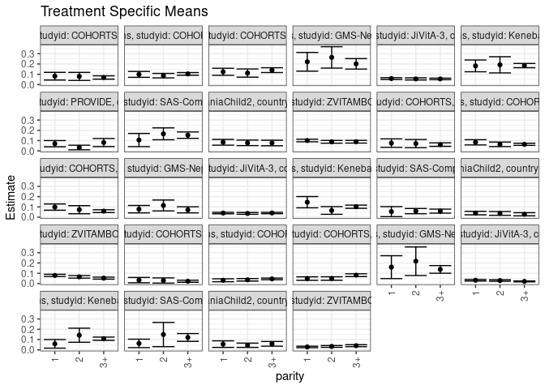

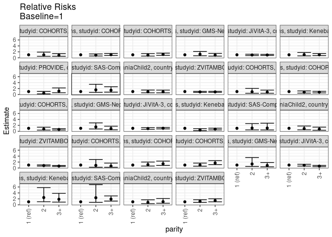

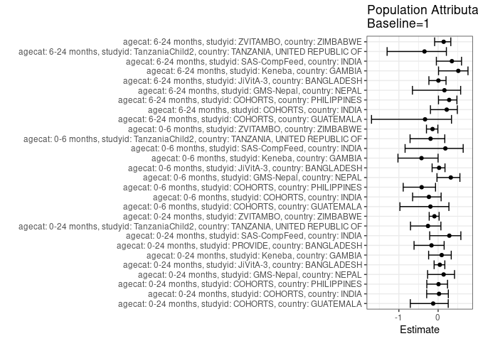

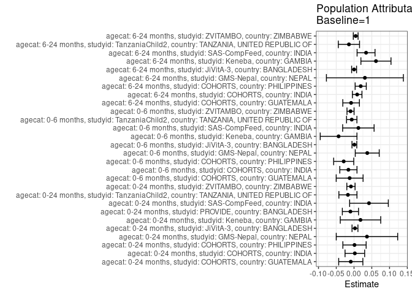

## Results Table

### Parameter: TSM

| agecat | studyid | country | intervention_level | baseline_level | estimate | ci_lower | ci_upper |
| --- | --- | --- | --- | --- | --- | --- | --- |
| 0-24 months | COHORTS | GUATEMALA | 1 | NA | 0.0814685 | 0.0441113 | 0.1188256 |
| 0-24 months | COHORTS | GUATEMALA | 2 | NA | 0.0793108 | 0.0402181 | 0.1184036 |
| 0-24 months | COHORTS | GUATEMALA | 3+ | NA | 0.0686356 | 0.0525076 | 0.0847636 |
| 0-24 months | COHORTS | INDIA | 1 | NA | 0.0991199 | 0.0703923 | 0.1278474 |
| 0-24 months | COHORTS | INDIA | 2 | NA | 0.0867264 | 0.0648182 | 0.1086347 |
| 0-24 months | COHORTS | INDIA | 3+ | NA | 0.1036178 | 0.0904873 | 0.1167482 |
| 0-24 months | COHORTS | PHILIPPINES | 1 | NA | 0.1241160 | 0.0895071 | 0.1587249 |
| 0-24 months | COHORTS | PHILIPPINES | 2 | NA | 0.1118364 | 0.0720787 | 0.1515942 |
| 0-24 months | COHORTS | PHILIPPINES | 3+ | NA | 0.1403666 | 0.1169648 | 0.1637684 |
| 0-24 months | GMS-Nepal | NEPAL | 1 | NA | 0.2215913 | 0.1304952 | 0.3126874 |
| 0-24 months | GMS-Nepal | NEPAL | 2 | NA | 0.2643832 | 0.1601812 | 0.3685852 |
| 0-24 months | GMS-Nepal | NEPAL | 3+ | NA | 0.2016047 | 0.1508080 | 0.2524014 |
| 0-24 months | JiVitA-3 | BANGLADESH | 1 | NA | 0.0583215 | 0.0494690 | 0.0671739 |
| 0-24 months | JiVitA-3 | BANGLADESH | 2 | NA | 0.0549568 | 0.0447033 | 0.0652102 |
| 0-24 months | JiVitA-3 | BANGLADESH | 3+ | NA | 0.0546898 | 0.0471505 | 0.0622291 |
| 0-24 months | Keneba | GAMBIA | 1 | NA | 0.1817971 | 0.1244441 | 0.2391501 |
| 0-24 months | Keneba | GAMBIA | 2 | NA | 0.1920970 | 0.1133752 | 0.2708188 |
| 0-24 months | Keneba | GAMBIA | 3+ | NA | 0.1847000 | 0.1640091 | 0.2053908 |
| 0-24 months | PROVIDE | BANGLADESH | 1 | NA | 0.0701107 | 0.0396891 | 0.1005323 |
| 0-24 months | PROVIDE | BANGLADESH | 2 | NA | 0.0327869 | 0.0104267 | 0.0551470 |
| 0-24 months | PROVIDE | BANGLADESH | 3+ | NA | 0.0810811 | 0.0417196 | 0.1204425 |
| 0-24 months | SAS-CompFeed | INDIA | 1 | NA | 0.1053179 | 0.0411083 | 0.1695275 |
| 0-24 months | SAS-CompFeed | INDIA | 2 | NA | 0.1659550 | 0.1081999 | 0.2237101 |
| 0-24 months | SAS-CompFeed | INDIA | 3+ | NA | 0.1529723 | 0.1219458 | 0.1839988 |
| 0-24 months | TanzaniaChild2 | TANZANIA, UNITED REPUBLIC OF | 1 | NA | 0.0837991 | 0.0559109 | 0.1116873 |
| 0-24 months | TanzaniaChild2 | TANZANIA, UNITED REPUBLIC OF | 2 | NA | 0.0782618 | 0.0513617 | 0.1051618 |
| 0-24 months | TanzaniaChild2 | TANZANIA, UNITED REPUBLIC OF | 3+ | NA | 0.0767266 | 0.0496590 | 0.1037942 |
| 0-24 months | ZVITAMBO | ZIMBABWE | 1 | NA | 0.1008621 | 0.0882471 | 0.1134772 |
| 0-24 months | ZVITAMBO | ZIMBABWE | 2 | NA | 0.0881947 | 0.0745182 | 0.1018713 |
| 0-24 months | ZVITAMBO | ZIMBABWE | 3+ | NA | 0.0891690 | 0.0757013 | 0.1026367 |

[output cut: 54 more lines]

### Parameter: E(Y)

| agecat | studyid | country | intervention_level | baseline_level | estimate | ci_lower | ci_upper |
| --- | --- | --- | --- | --- | --- | --- | --- |
| 0-24 months | COHORTS | GUATEMALA | NA | NA | 0.0723341 | 0.0584645 | 0.0862036 |
| 0-24 months | COHORTS | INDIA | NA | NA | 0.1014273 | 0.0927249 | 0.1101298 |
| 0-24 months | COHORTS | PHILIPPINES | NA | NA | 0.1254516 | 0.1136848 | 0.1372183 |
| 0-24 months | GMS-Nepal | NEPAL | NA | NA | 0.2580175 | 0.2252514 | 0.2907836 |
| 0-24 months | JiVitA-3 | BANGLADESH | NA | NA | 0.0610254 | 0.0575469 | 0.0645038 |
| 0-24 months | Keneba | GAMBIA | NA | NA | 0.2000000 | 0.1824211 | 0.2175789 |
| 0-24 months | PROVIDE | BANGLADESH | NA | NA | 0.0600000 | 0.0423945 | 0.0776055 |
| 0-24 months | SAS-CompFeed | INDIA | NA | NA | 0.1473893 | 0.1184132 | 0.1763654 |
| 0-24 months | TanzaniaChild2 | TANZANIA, UNITED REPUBLIC OF | NA | NA | 0.0666101 | 0.0565417 | 0.0766785 |
| 0-24 months | ZVITAMBO | ZIMBABWE | NA | NA | 0.0922194 | 0.0874171 | 0.0970218 |
| 0-6 months | COHORTS | GUATEMALA | NA | NA | 0.0630292 | 0.0484135 | 0.0776449 |
| 0-6 months | COHORTS | INDIA | NA | NA | 0.0675068 | 0.0601293 | 0.0748842 |
| 0-6 months | COHORTS | PHILIPPINES | NA | NA | 0.0693167 | 0.0602923 | 0.0783411 |
| 0-6 months | GMS-Nepal | NEPAL | NA | NA | 0.1151603 | 0.0912555 | 0.1390652 |
| 0-6 months | JiVitA-3 | BANGLADESH | NA | NA | 0.0413642 | 0.0383846 | 0.0443438 |
| 0-6 months | Keneba | GAMBIA | NA | NA | 0.1026472 | 0.0888174 | 0.1164771 |
| 0-6 months | SAS-CompFeed | INDIA | NA | NA | 0.0664452 | 0.0425975 | 0.0902929 |
| 0-6 months | TanzaniaChild2 | TANZANIA, UNITED REPUBLIC OF | NA | NA | 0.0335172 | 0.0262496 | 0.0407848 |
| 0-6 months | ZVITAMBO | ZIMBABWE | NA | NA | 0.0687987 | 0.0645835 | 0.0730139 |
| 6-24 months | COHORTS | GUATEMALA | NA | NA | 0.0247321 | 0.0159885 | 0.0334756 |
| 6-24 months | COHORTS | INDIA | NA | NA | 0.0403319 | 0.0344774 | 0.0461864 |
| 6-24 months | COHORTS | PHILIPPINES | NA | NA | 0.0669277 | 0.0576848 | 0.0761707 |
| 6-24 months | GMS-Nepal | NEPAL | NA | NA | 0.1898305 | 0.1581595 | 0.2215015 |
| 6-24 months | JiVitA-3 | BANGLADESH | NA | NA | 0.0319690 | 0.0290813 | 0.0348568 |
| 6-24 months | Keneba | GAMBIA | NA | NA | 0.1200624 | 0.1055350 | 0.1345898 |
| 6-24 months | SAS-CompFeed | INDIA | NA | NA | 0.0964723 | 0.0729872 | 0.1199573 |
| 6-24 months | TanzaniaChild2 | TANZANIA, UNITED REPUBLIC OF | NA | NA | 0.0412682 | 0.0325201 | 0.0500164 |
| 6-24 months | ZVITAMBO | ZIMBABWE | NA | NA | 0.0329203 | 0.0295572 | 0.0362834 |

### Parameter: RR

| agecat | studyid | country | intervention_level | baseline_level | estimate | ci_lower | ci_upper |
| --- | --- | --- | --- | --- | --- | --- | --- |
| 0-24 months | COHORTS | GUATEMALA | 1 | 1 | 1.0000000 | 1.0000000 | 1.0000000 |
| 0-24 months | COHORTS | GUATEMALA | 2 | 1 | 0.9735157 | 0.4965465 | 1.9086486 |
| 0-24 months | COHORTS | GUATEMALA | 3+ | 1 | 0.8424808 | 0.5032562 | 1.4103630 |
| 0-24 months | COHORTS | INDIA | 1 | 1 | 1.0000000 | 1.0000000 | 1.0000000 |
| 0-24 months | COHORTS | INDIA | 2 | 1 | 0.8749651 | 0.5957789 | 1.2849798 |
| 0-24 months | COHORTS | INDIA | 3+ | 1 | 1.0453782 | 0.7620581 | 1.4340318 |
| 0-24 months | COHORTS | PHILIPPINES | 1 | 1 | 1.0000000 | 1.0000000 | 1.0000000 |
| 0-24 months | COHORTS | PHILIPPINES | 2 | 1 | 0.9010637 | 0.5735224 | 1.4156655 |
| 0-24 months | COHORTS | PHILIPPINES | 3+ | 1 | 1.1309308 | 0.8172902 | 1.5649332 |
| 0-24 months | GMS-Nepal | NEPAL | 1 | 1 | 1.0000000 | 1.0000000 | 1.0000000 |
| 0-24 months | GMS-Nepal | NEPAL | 2 | 1 | 1.1931117 | 0.6752765 | 2.1080485 |
| 0-24 months | GMS-Nepal | NEPAL | 3+ | 1 | 0.9098042 | 0.5617802 | 1.4734300 |
| 0-24 months | JiVitA-3 | BANGLADESH | 1 | 1 | 1.0000000 | 1.0000000 | 1.0000000 |
| 0-24 months | JiVitA-3 | BANGLADESH | 2 | 1 | 0.9423076 | 0.7378373 | 1.2034409 |
| 0-24 months | JiVitA-3 | BANGLADESH | 3+ | 1 | 0.9377303 | 0.7664512 | 1.1472853 |
| 0-24 months | Keneba | GAMBIA | 1 | 1 | 1.0000000 | 1.0000000 | 1.0000000 |
| 0-24 months | Keneba | GAMBIA | 2 | 1 | 1.0566562 | 0.6299111 | 1.7725079 |
| 0-24 months | Keneba | GAMBIA | 3+ | 1 | 1.0159676 | 0.7269689 | 1.4198546 |
| 0-24 months | PROVIDE | BANGLADESH | 1 | 1 | 1.0000000 | 1.0000000 | 1.0000000 |
| 0-24 months | PROVIDE | BANGLADESH | 2 | 1 | 0.4676445 | 0.2083855 | 1.0494558 |
| 0-24 months | PROVIDE | BANGLADESH | 3+ | 1 | 1.1564723 | 0.6030613 | 2.2177317 |
| 0-24 months | SAS-CompFeed | INDIA | 1 | 1 | 1.0000000 | 1.0000000 | 1.0000000 |
| 0-24 months | SAS-CompFeed | INDIA | 2 | 1 | 1.5757532 | 0.7204119 | 3.4466369 |
| 0-24 months | SAS-CompFeed | INDIA | 3+ | 1 | 1.4524817 | 0.8049257 | 2.6209910 |
| 0-24 months | TanzaniaChild2 | TANZANIA, UNITED REPUBLIC OF | 1 | 1 | 1.0000000 | 1.0000000 | 1.0000000 |
| 0-24 months | TanzaniaChild2 | TANZANIA, UNITED REPUBLIC OF | 2 | 1 | 0.9339212 | 0.5795043 | 1.5050947 |
| 0-24 months | TanzaniaChild2 | TANZANIA, UNITED REPUBLIC OF | 3+ | 1 | 0.9156015 | 0.5635527 | 1.4875738 |
| 0-24 months | ZVITAMBO | ZIMBABWE | 1 | 1 | 1.0000000 | 1.0000000 | 1.0000000 |
| 0-24 months | ZVITAMBO | ZIMBABWE | 2 | 1 | 0.8744088 | 0.7164537 | 1.0671881 |
| 0-24 months | ZVITAMBO | ZIMBABWE | 3+ | 1 | 0.8840683 | 0.7266410 | 1.0756023 |

[output cut: 54 more lines]

### Parameter: PAR

| agecat | studyid | country | intervention_level | baseline_level | estimate | ci_lower | ci_upper |
| --- | --- | --- | --- | --- | --- | --- | --- |
| 0-24 months | COHORTS | GUATEMALA | 1 | NA | -0.0091344 | -0.0431388 | 0.0248700 |
| 0-24 months | COHORTS | INDIA | 1 | NA | 0.0023075 | -0.0253007 | 0.0299156 |
| 0-24 months | COHORTS | PHILIPPINES | 1 | NA | 0.0013355 | -0.0314284 | 0.0340995 |
| 0-24 months | GMS-Nepal | NEPAL | 1 | NA | 0.0364262 | -0.0500065 | 0.1228589 |
| 0-24 months | JiVitA-3 | BANGLADESH | 1 | NA | 0.0027039 | -0.0056036 | 0.0110114 |
| 0-24 months | Keneba | GAMBIA | 1 | NA | 0.0182029 | -0.0387083 | 0.0751141 |
| 0-24 months | PROVIDE | BANGLADESH | 1 | NA | -0.0101107 | -0.0328889 | 0.0126675 |
| 0-24 months | SAS-CompFeed | INDIA | 1 | NA | 0.0420714 | -0.0123684 | 0.0965112 |
| 0-24 months | TanzaniaChild2 | TANZANIA, UNITED REPUBLIC OF | 1 | NA | -0.0171890 | -0.0426143 | 0.0082363 |
| 0-24 months | ZVITAMBO | ZIMBABWE | 1 | NA | -0.0086427 | -0.0202615 | 0.0029761 |
| 0-6 months | COHORTS | GUATEMALA | 1 | NA | -0.0123590 | -0.0501589 | 0.0254408 |
| 0-6 months | COHORTS | INDIA | 1 | NA | -0.0158284 | -0.0400022 | 0.0083453 |
| 0-6 months | COHORTS | PHILIPPINES | 1 | NA | -0.0290671 | -0.0573354 | -0.0007988 |
| 0-6 months | GMS-Nepal | NEPAL | 1 | NA | 0.0372454 | 0.0035373 | 0.0709534 |
| 0-6 months | JiVitA-3 | BANGLADESH | 1 | NA | 0.0010267 | -0.0057348 | 0.0077882 |
| 0-6 months | Keneba | GAMBIA | 1 | NA | -0.0434493 | -0.0951131 | 0.0082145 |
| 0-6 months | SAS-CompFeed | INDIA | 1 | NA | 0.0122446 | -0.0320036 | 0.0564928 |
| 0-6 months | TanzaniaChild2 | TANZANIA, UNITED REPUBLIC OF | 1 | NA | -0.0064706 | -0.0210314 | 0.0080903 |
| 0-6 months | ZVITAMBO | ZIMBABWE | 1 | NA | -0.0098153 | -0.0197857 | 0.0001551 |
| 6-24 months | COHORTS | GUATEMALA | 1 | NA | -0.0082350 | -0.0316403 | 0.0151703 |
| 6-24 months | COHORTS | INDIA | 1 | NA | 0.0088429 | -0.0046323 | 0.0223182 |
| 6-24 months | COHORTS | PHILIPPINES | 1 | NA | 0.0188593 | 0.0032055 | 0.0345131 |
| 6-24 months | GMS-Nepal | NEPAL | 1 | NA | 0.0305744 | -0.0777161 | 0.1388648 |
| 6-24 months | JiVitA-3 | BANGLADESH | 1 | NA | 0.0002256 | -0.0066963 | 0.0071476 |
| 6-24 months | Keneba | GAMBIA | 1 | NA | 0.0617233 | 0.0193732 | 0.1040733 |
| 6-24 months | SAS-CompFeed | INDIA | 1 | NA | 0.0338647 | 0.0086273 | 0.0591020 |
| 6-24 months | TanzaniaChild2 | TANZANIA, UNITED REPUBLIC OF | 1 | NA | -0.0143285 | -0.0442057 | 0.0155487 |
| 6-24 months | ZVITAMBO | ZIMBABWE | 1 | NA | 0.0046657 | -0.0020771 | 0.0114084 |

### Parameter: PAF

| agecat | studyid | country | intervention_level | baseline_level | estimate | ci_lower | ci_upper |
| --- | --- | --- | --- | --- | --- | --- | --- |
| 0-24 months | COHORTS | GUATEMALA | 1 | NA | -0.1262804 | -0.7088117 | 0.2576669 |
| 0-24 months | COHORTS | INDIA | 1 | NA | 0.0227499 | -0.2910748 | 0.2602925 |
| 0-24 months | COHORTS | PHILIPPINES | 1 | NA | 0.0106459 | -0.2882169 | 0.2401734 |
| 0-24 months | GMS-Nepal | NEPAL | 1 | NA | 0.1411772 | -0.2680935 | 0.4183579 |
| 0-24 months | JiVitA-3 | BANGLADESH | 1 | NA | 0.0443081 | -0.1018849 | 0.1711048 |
| 0-24 months | Keneba | GAMBIA | 1 | NA | 0.0910145 | -0.2418555 | 0.3346612 |
| 0-24 months | PROVIDE | BANGLADESH | 1 | NA | -0.1685117 | -0.6132761 | 0.1536356 |
| 0-24 months | SAS-CompFeed | INDIA | 1 | NA | 0.2854441 | -0.2147682 | 0.5796810 |
| 0-24 months | TanzaniaChild2 | TANZANIA, UNITED REPUBLIC OF | 1 | NA | -0.2580541 | -0.7036020 | 0.0709684 |
| 0-24 months | ZVITAMBO | ZIMBABWE | 1 | NA | -0.0937188 | -0.2273057 | 0.0253277 |
| 0-6 months | COHORTS | GUATEMALA | 1 | NA | -0.1960840 | -0.9735642 | 0.2751100 |
| 0-6 months | COHORTS | INDIA | 1 | NA | -0.2344720 | -0.6499997 | 0.0764112 |
| 0-6 months | COHORTS | PHILIPPINES | 1 | NA | -0.4193380 | -0.8896764 | -0.0660663 |
| 0-6 months | GMS-Nepal | NEPAL | 1 | NA | 0.3234218 | -0.0292761 | 0.5552621 |
| 0-6 months | JiVitA-3 | BANGLADESH | 1 | NA | 0.0248201 | -0.1530314 | 0.1752386 |
| 0-6 months | Keneba | GAMBIA | 1 | NA | -0.4232874 | -1.0236367 | -0.0010428 |
| 0-6 months | SAS-CompFeed | INDIA | 1 | NA | 0.1842814 | -0.8418998 | 0.6387443 |
| 0-6 months | TanzaniaChild2 | TANZANIA, UNITED REPUBLIC OF | 1 | NA | -0.1930522 | -0.7150007 | 0.1700449 |
| 0-6 months | ZVITAMBO | ZIMBABWE | 1 | NA | -0.1426665 | -0.2971232 | -0.0066020 |
| 6-24 months | COHORTS | GUATEMALA | 1 | NA | -0.3329670 | -1.6972387 | 0.3412518 |
| 6-24 months | COHORTS | INDIA | 1 | NA | 0.2192541 | -0.1954048 | 0.4900773 |
| 6-24 months | COHORTS | PHILIPPINES | 1 | NA | 0.2817858 | 0.0097302 | 0.4790999 |
| 6-24 months | GMS-Nepal | NEPAL | 1 | NA | 0.1610613 | -0.6544867 | 0.5746003 |
| 6-24 months | JiVitA-3 | BANGLADESH | 1 | NA | 0.0070577 | -0.2348613 | 0.2015828 |
| 6-24 months | Keneba | GAMBIA | 1 | NA | 0.5140932 | 0.0112074 | 0.7612185 |
| 6-24 months | SAS-CompFeed | INDIA | 1 | NA | 0.3510301 | -0.0445179 | 0.5967882 |
| 6-24 months | TanzaniaChild2 | TANZANIA, UNITED REPUBLIC OF | 1 | NA | -0.3472048 | -1.2999942 | 0.2108846 |
| 6-24 months | ZVITAMBO | ZIMBABWE | 1 | NA | 0.1417264 | -0.0888094 | 0.3234503 |